# Reproducible and collaborative workflows

Cylcia Bolibaugh

01/07/2021

## Setting up a reproducible and collaborative workflow

#### Context

I have moved almost entirely to using Papaja and Rmarkdown for writing manuscripts that integrate the analyses underlying the output. Because most of my collaborators do not use these tools, I most frequently output to word documents for collaboration and submission. I prefer to write text collaboratively in Google Docs because of the built in version control, track changes and comments. It is also sufficiently similar to Word for most collaborators to get on with. Finally the ability to render a .Rmd to Word means that I can upload and convert this to to Google Doc to take advantage of these features.

There are some downsides to this workflow. Working in Google Docs for collaborative text drafting means that changes made there have to be manually integrated in the working Rmd document that contains the dynamically generated analyses and other related output. While the workflow is generally manageable, unless I am really on top of integrating text changes into the .Rmd, there is a risk that I lose track of which changes I have integrated. The process can be particularly finicky when carrying out small changes throughout a manuscript (e.g. as can happen during rounds of review & resubmit).

#### Aims

I’m writing this post in order to formalise (and document) my working practices so that I can share them with my PhDs and other interested colleagues. My two main goals are 1) to make the use of version control for the code in my analyses the default procedure, and 2) to find a sustainable way to collaborate with others who may not be familiar with R and Rmarkdown when writing, specifically using Google Docs.

I aim to document both parts of this workflow through the writing of this post. Part I consists of setting up a repository for new projects on Github, and Part II involves making use of the new [trackdown package](https://ekothe.github.io/trackdown/articles/trackdown-workflow.html) to generate a Google Doc from an Rmarkdown document, which can then be shared with collaborators.

To test the whole workflow, I intersperse my comments on the *process* with a sample report of a fake study.

The idea of documenting my process is drawn (as many things are) from Jenny Bryan, and [Stat545](https://stat545.com/random.html):

> I recently needed to draw a f*cking owl in R, so I decided to record the process as an experiment.

#### Part I - Maintaining version control for code

This workflow assumes that we are going to use to Git + Github to keep track of code changes.

Resources: https://cfss.uchicago.edu/setup/git-with-rstudio/

1. Create a new project repository

As a first step, follow the instructions above (I already have Git set up and linked to RStudio, and a Github account), and create a new repository. I titled mine reproducible-workflows for this post. Then start a new project locally by cloning the repository, edit the read-me and push it back to check everything is working.

2. Create a new rmarkdown file, and add some code.

Let’s test it out using some simulated data from a fake study.

#### ——- Fake study report pt 1 - Benefits of petting dogs before exams ——-

A recent study suggested that spending time with a pet acts as a buffer against psychological stress (Ratschen et al., 2020). Imagine that we conducted an experiment to explore whether this effect generalised to stress caused by university exams. Specifically, we hypothesised that students who spent time with a university health and wellbeing dog before an exam would have fewer feelings of stress relative to students who only looked at pictures of dogs before an exam. In order to test the hypothesis we recruited 200 students who had imminent exams and self-reported that they felt stressed, and assigned half of them to pet the university dog, and half to look through a catalogue of dog pictures. We then assessed how stressed they felt on the Stress-o-metre Scale (1-100).

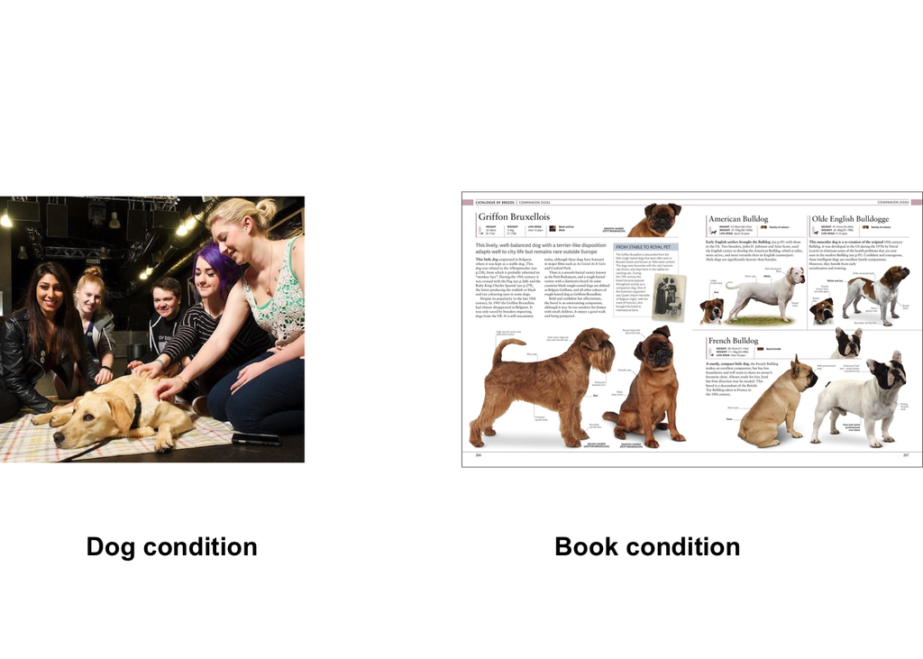

Study conditions

(For the purposes of this simulation, we have a simple between subjects design, where the independent (grouping) variable has two levels, and the dependent variable is from a normal distribution.)

```r
#simulate normally distributed data for an independent samples t-test
muA <- 50 #what's the population mean for condition A?
muB <- 55 #what's the population mean for condition B?

n1 <- 100 #how many participants group A?
n2 <- 100 #how many participants group B?

sigma1 <- 20 #population standard deviation of condition A?
sigma2 <- 20 #population standard deviation of condition B?
```

We then generate the scores using the `rnorm()` function, then plot the distribution of scores for each group.

```r
A_scores <- rnorm(n1,muA,sigma1) #simulate a vector of 100 deviates from normal distribution
B_scores <- rnorm(n2,muB,sigma2) #simulate a vector of 100 deviates from normal distribution
```

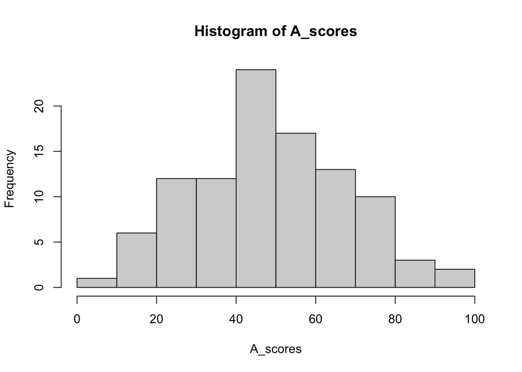

Figure 1: Distribution of scores from Group A

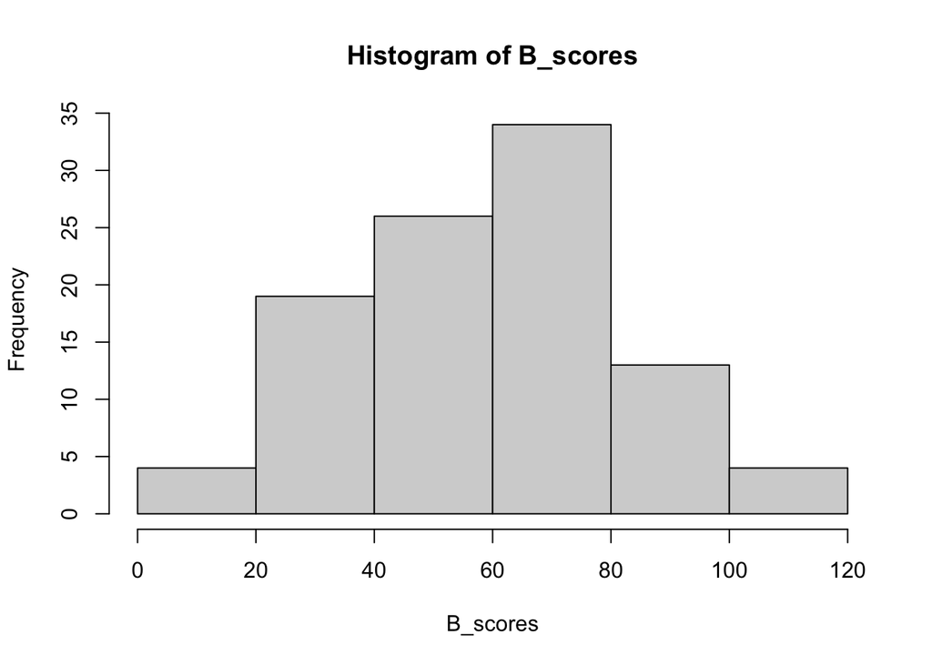

Figure 2: Distribution of scores from Group B

I can now run my inferential test on my new data.

(Note that we didn’t set the seed, so the results may or may not be significant each time we render the document.)

Ratschen E, Shoesmith E, Shahab L, Silva K, Kale D, Toner P, et al. (2020) Human-animal relationships and interactions during the Covid-19 lockdown phase in the UK: Investigating links with mental health and loneliness. PLoS ONE 15(9): e0239397. [<https://doi.org/10.1371/journal.pone.0239397>](https://doi.org/10.1371/journal.pone.0239397)

#### —- End of Fake study report pt 1 ——–

Once I have finished my analysis and pushed the changes, I am going to share these exciting results with my (imaginary) collaborators so that we can craft the discussion section of our paper together. This is where Part II of the reproducible, collaborative workflow and the `trackdown` package comes in.

#### Part II - Writing text collaboratively in Google Docs

Resources: https://ekothe.github.io/trackdown/

1) Working in RStudio to create a new Google Doc

The `trackdown` package isn’t on CRAN yet, and so needs to be installed directly:

`remotes::install_github("ekothe/trackdown",build_vignettes = TRUE)`

Following the workflow vignette, I now use the `upload_file()` function to create a Google doc in my Google Drive from the present Rmarkdown file. I have followed their suggestion to hide the code so that collaborators don’t accidentally overwrite anything they don’t understand when we are creating the narrative portion of the text, but I can imagine circumstances (working with my own PhDs) where I wouldn’t want to do this.

Reading the documentation for the `upload_file()` function tells us that we want to specify the file (path of the local. Rmd), and there are further arguments that I won’t change for now.

Running the `upload_file()` function for the first time, I see a dialogue that requests permission for caching OAuth access credentials in a folder between sessions. I am not sure about this, but will say yes given this is not a sensitive file.

> `→ Is it OK to cache OAuth access credentials in the folder ~/Library/Caches/gargle between R sessions?`

Once I execute the command, I am then prompted (in a new browser tab – note that I was signed in to gmail at the time) to choose which Google account I wanted to use, and to grant access to the Tidy… API.

Once granted, I receive a further prompt asking if I want to create the `trackdown` folder in my Drive:

> `Folder ‘trackdown/’ does not exists in GoogleDrive. Do you want to create it?`

An important note is that you probably *don’t* want to specify the `upload_file()` function as a code chunk that will be run whenever you knit the document. Doing so caused an error when I knit, so best to run in the console.

So far, so good. Now let’s go to Google Drive and see what’s there.

Working in Google Drive

Opening my Drive, I see that my new document (with the same name as the .Rmd) is the first item suggested to me (since it is the most recently created document).

Unfortunately, I spot my first problem. During the process of creating the Google Doc, I recorded the various queries and warnings as they appeared in the .Rmd itself. Unsurprisingly, the Google Doc doesn’t contain any of the text that I wrote after the evaluation of the `upload_file()` function. The next step should inform me how the `trackdown` package resolves conflicts.

A few points to note first. The new Google Doc has the same title as the .rmd, and because I’ve chosen to hide the code, any *code chunks* are hidden. However, since I used in-text reporting of the results of my analysis, these are still there, and could potentially be confusing to a non-r-literate collaborator.

Another important note, is that `trackdown` adds a commentary at the top of the document to inform the readers that this is a rather *special* type of document. If a collaborator reads these carefully, they *might* be less likely to pepper me with questions:

> —-Trackdown Instructions—- This is not a common Document. The Document includes properly formatted Markdown syntax and R code. Please be aware and responsible in making corrections as you could break the code. Limit changes to narrative text and avoid modifying R code. Please do not remove placeholders of type “[[chunk-]]” or “[[document-header]]” Once the review is over accept all changes: Tools -> Review suggested edits -> Accept all. You must not modify or remove these lines, we will do it for you ;) FILE-NAME: Reproducible_collaborative_workflows.Rmd HIDE-CODE: TRUE —-End Instructions—-

If I were sharing with a collaborator, this would be the point at which I would share the link. An important point to note is that any changes made to the document in Suggestion Mode, and any comments, need to be accepted before the document is reconciled with the local .Rmd.

Since I don’t have a collaborator other than myself at the moment, let’s download the Google Doc back into Rmd format and see whether/how conflicts are resolved.

Looking at the `download_file()` function vignette (https://ekothe.github.io/trackdown/reference/download_file.html), I find the answer to my question:

> Use with caution as local version of the file will be overwritten!

So in preparation for downloading, I copy the excess text that I worked on into another .rmd. Hopefully I won’t make this mistake again. The bottom line is that merge conflicts are not elegantly dealt with, so it pays to be clear which document is active or ‘live’ at any point.

Rather than hard coding the download command into my script, I will run it from the console (although it might be better to put it in and comment it out in order to keep track of the points at which the document changed).

> `trackdown::download_file(file = "Path-to-file/My-Report.Rmd")`

After running this in the console, I am duly warned that downloading will overwrite my local file, and have to confirm that I want to do this. Once I agree I am prompted to reload my file and ta-da, the text I wrote in Google Docs is now in my .Rmd document.

Having learned my lesson the hard way, I’ll now copy back in the notes from my local copy that I have saved once I knew they would be overwritten, and knit the document to see what it looks like.

To finish off, I’ll add some more code in my fake study report, and push the latest version back to Github.

#### ——– Fake Study Report pt 2 ——————–

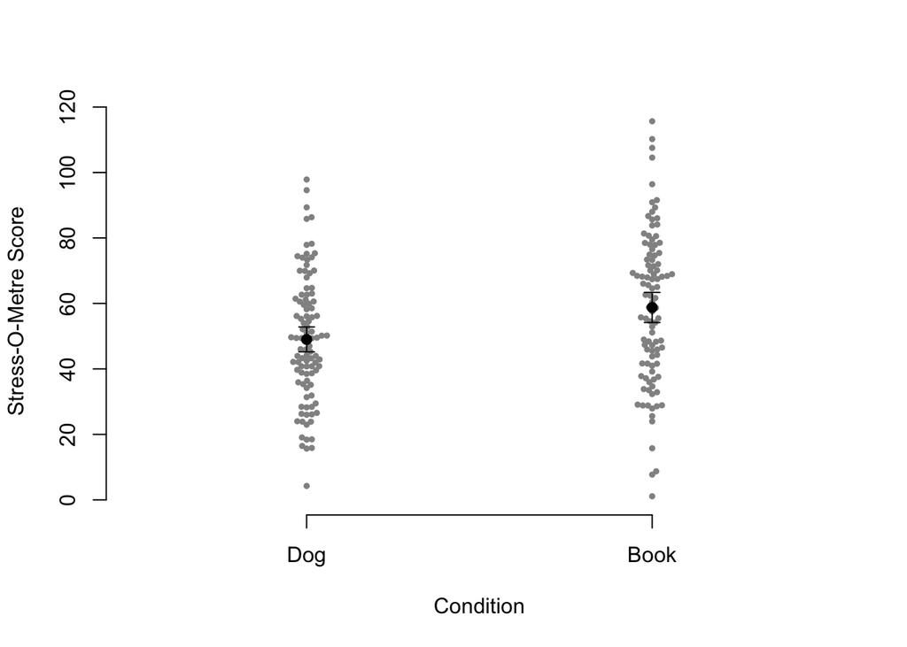

Figure 3: Stress after either petting dog or looking at dog pictures

#### ——– End Fake Study Report pt 2 ——————–

Interestingly, the `trackdown` package has generated a folder with two Rds files. Given that I’m not sure when these are updated, I’ll commit and push them as well.

### General comments

The process does seem to work, but not painlessly. The issue that will need to be considered is how to on-board collaborators. It will likely require some more “clued-up” collaborators, since the Google Doc contains all of the Markdown formatting, and the vignettes specify that any formatting applied in the Google Doc is not converted to markdown when downloaded (requiring the lead collaborator to enact any formatting changes manually).

One option which I didn’t try is to render the .Rmd document to another format and upload it alongside the Google Doc for collaborators to be able to see what a finished version of the text + figures/in-line reports. This is possible using the `path_output` argument of `upload_` and `update_file()`.

At present, this workflow seems most suited to keeping track of my own work and versions. My most common use-case is where I am corresponding author on a manuscript that goes through several cycles of revisions, but doesn’t have substantial changes to the figures or analyses. I have been trying to move to writing everything in `papaja` but then wind up with changes in the text in a rendered word document that I have to manually track back into the .Rmd. This is a major pain.

Where this workflow might be less useful is in working with my PhDs as collaborators. Here I am often reviewing and writing code as well as text, and might need to follow both steps above for a project.

Finally, I think this workflow can work with Papaja. A key might be to do most of the processing work in r scripts which are then called in via `source()` so as to minimise the code intrusions, and upload a rendered .docx file to look at the layout.

## A more realistic example

As noted above, I now most frequently start most projects using a Papaja template. So let’s see how that would play out.

Within the present project, I am now going to create a new Rmd from the Papaja manuscript template, and populate it with some details from my fake study.

### Creating a new papaja document

In order to create a new manuscript, I now open a new RMD with the Papaja manuscript template add-in, and populate it with the text and code from the fake study included above. I knit the document to word to check that it renders. I now have two choices: push to Github, or use trackdown to render a gdoc. I think I will push to GIT first.

After committing and pushing, I now have my new .Rmd and .doc files in github, alongside the Papaja generated figures file. I’m now going to use the trackdown package to upload it. This time I will be uploading not only the Rmd to be converted to a google doc, but the rendered word doc for a hypothetical collaborator to look at and see the rendering of inline code and figures.

Ok, back to the vignettes. I will need to run: upload_file( file, gfile = NULL, gpath = “trackdown”, shared_drive = NULL, hide_code = FALSE, path_output = NULL )

where file is the path to the .Rmd, and path_output is the path to the word doc. I’m not sure what to do with the figures folder that is generated by papaja. Given that it’s not necessary for editing text in Google docs, I will leave it.

Once I run the command, I receive the following message

> ── Uploading files to Google Drive ────────────────────────────────────────────────────────────────────────────────────────────────────────────────────────────

> → The googledrive package is requesting access to your Google account Select a pre-authorised account or enter ‘0’ to obtain a new token Press Esc/Ctrl + C to cancel

> 1: cylcia.bolibaugh@york.ac.uk

Well, after a relatively long wait, I received an error message telling me that the file did not exist. I see that the file is the rendered doc, and notice I’ve left an x off the end. let’s try again. Ok, still no joy. I’ve noticed that the rendered doc is hyphenated between each word, so let’s try that;

Ok, success! > • Removing code… ✓ Code removed from Benefits of petting dogs.Rmd • Uploading document to Google Drive… ✓ Document uploaded at trackdown/Benefits of petting dogs • Uploading output to Google Drive… ✓ Output uploaded at trackdown/Benefits of petting dogs-output ✓ Process completed!

Opening the “trackdown” folder in Google Drive, I see that I indeed have copies of both files, the Rmd which has been transformed to a google doc, and the word output. The word document has “-output” appended to the title to make it easy to recognise.

Now the key communication with collaborators will be to tell them that the ouput document is READ_ONLY. It’s purpose is solely to give them an idea of what the formatted manuscript, including output of figures, and in-line code reporting, look like. Any editing should be performed on the Google Doc. As noted above, any formatting that is added to the Google Doc will not survive the download back to .Rmd, so this needs to be highlighted as well.

I now add a bit of text to the end of my document (laying out a few of our hypothetical study’s many methodological shortcomings) and then download back to .Rmd using the trackdown::download_file() command. Note that there is another command called render_file() which says that it will render the new changes, but I will do this manually.

Another important point to note, is that it might be worth including the upload and download chunks in the manuscript at the beginning, before the initial upload. Otherwise they are overwritten. Hmmm, another hiccup, as it says the versions are identical and it will abort. The versions are not the same, so I will try again. Ok, success!

A final point involves using the last update_file() function. reading the documentation, it says: > Use with caution as tracked changes in the Google Drive file will be lost!

So this is a key limitation of the workflow. Using trackdown enables you to share with collaborators and to used tracked changes ‘suggested’ mode, as well as comments, but when you ‘push’ an update from local to Drive, it overwrites the google doc and thus disables the version control.

Coming back a week later, and having now tried this, the good news is that this is not the case. Previous versions of the document are available via Gdoc’s standard version control toggle, and reverting to a previous version (where changes are tracked) is possible.

Ok, I’m going to push all these changes to Github, and tomorrow come back to add a last bit of code change to the manuscript, and try out the update file command.

#### A few tips for collaborating in Google Docs

1. Make use of the `path output` parameter in the `upload-file()` and`update_file()` functions to upload the rendered and formatted Word document as well as the google doc version of the markdown formatted manuscript. This will enable collaborators to read through the document with figures, and in-line output in place.
2. When sharing with collaborators on Google Drive, do not share the whole project folder content with the same permissions. Instead, share the output Word doc as “read only” to ensure that edits do not happen here, and share the Google Doc version of the Rmd with editing permissions.
3. Set `hide_code = TRUE` in the `upload-file()` and`update_file()` functions if you are working with collaborators who are not code-savvy. This is probably good practice in all cases because anyone reviewing the code should be working from the Github repo, and the Google Drive uploads should be for text edits only.
4. If there is a lot of data processing in the Rmd, the number of “hidden” code chunks in the Google Doc can start to be visually disorienting. Here a better practice is likely to be creating separate .Rmd or .R files for analyses that are sourced in the main Papaja .Rmd.
5. Think about how to initiate collaborators to this way of working. It might be worth creating a brief onboarding document that re-iterates the text `Trackdown` places at the start of the Google Doc to explain how to interact with it.
6. When working with a template like Papaja, include 3 separate chunks to use the `Trackdown` commands at the beginning or end of the manuscript. (I find it easier to keep them at the end.) All of these chunks should be set with options `eval = FALSE` and `include = FALSE` so they are not run when you knit the document. For this demonstration document, I’ve created the following three chunks (named `track-upload`, `track-update` and `track-download`) that I can run manually as needed:

```r
upload_file(file = "Benefits of petting dogs.Rmd",
  gfile = NULL,
  gpath = "trackdown",
  shared_drive = NULL,
  hide_code = TRUE,
  path_output = "Benefits-of-petting-dogs.docx"
)
```

```r
trackdown::update_file(
  file = "Benefits of petting dogs.Rmd",
  gfile = NULL,
  gpath = "trackdown",
  shared_drive = NULL,
  hide_code = TRUE,
  path_output = "Benefits-of-petting-dogs.docx"
)
```

```r
trackdown::download_file(
  file = "Benefits of petting dogs.Rmd",
  gfile = NULL,
  gpath = "trackdown",
  shared_drive = NULL)
```